# Final Project

### Anuj Sinha - 2323928

## 1. Describe the dataset you chose. Why did you choose it? What features does it include? What year is it from? How was it collected? What should we know about this dataset as we read your write-up? (8pts)

**Dataset:** I have chosen the heart disease dataset from Kaggle. The link for the dataset is given below.

https://www.kaggle.com/datasets/johnsmith88/heart-disease-dataset

The dataset consists of 14 columns about human age, sex, and different human-body medical readings as well as a column that signifies the presence of heart disease.

**Reason for Choice:** I chose this dataset because of the following reasons:

- My interest in Applied Data Science in the Healthcare Industry.
- In India, there are a lot of doctor-owned private clinics of various specialties - (like cardiologists, general physicians, medicine, nephrologists, and neurologists, etc). These clinics are not financially big enough to afford complicated models available in the market. That being said, they can still use models that have been trained on the dataset of their patient directory (assuming around 1K - 3K per clinic). The estimate of this number is based on the fact that an average private clinic in India might see 5-8 new patients every day. Building a model that is roughly on the same data scale will help me lay a foundation for building a Software Solution for the same.

**Year of Data Collection:** 1988

**Data Collection Procedure:** The dataset has been sourced from four regions of Cleveland, Hungary, Switzerland, and Long Beach V. The initial data collection contained more than 76 columns. After consultation with medical field experts, ML researchers reduced the number of columns to 14 as described above for research and ML study purposes.

**Things to Know About the Dataset:**

- The size of the dataset: 1025
- Skew of the dataset: 499 entries where target = 0 (disease NOT detected); 526 entries where target = 1 (disease detected)
- The dataset is relatively clean with no NA entries in the dataset.

## 2. Define a research question. What are you trying to predict? Describe what you’re trying to accomplish (it will differ between Supervised and Unsupervised learning). (4pts)

Research Questions to Answer:

1. Given the subset of 13 independent variables of the dataset, can we accurately predict the presence or absence of a heart condition for a patient?
2. What are the top 3 independent variables (bodily conditions/readings) that have a strong direct or inverse correlation with the "target" variable?
3. What is the highest recall score that we can achieve for this classification problem?

In this problem set, I am trying to develop a machine-learning model that will take as input the above-mentioned 13 independent variables and predict the "target" variable (presence or absence of heart disease as output.) The trained model should be able to predict the presence/absence of heart disease with **HIGH Accuracy.**

Since this is a classification model, I will also try to accomplish a **HIGH Recall Score**. This is to ensure that the model does not have a high number of False negatives. In the medical industry, models having low recall scores can prove fatal for the patients diagnosed with the help of that model.

## 3. Why is this algorithm a good way of answering your research question? (4pts)

I have chosen the K-Nearest-Neighbours Classifier as the algorithm. I have chosen this algorithm because the problem we are solving is a **supervised learning classification problem**. The KNN algorithm is one of the classification algorithms that can be easily explained to the stakeholders. When analyzing the performance and correlation between input, output, and data, it is easier to understand the workings of the model. **I believe this is one of the important criteria when developing models related to the field of medical science. Blackbox models can negatively impact the study and analysis with unobserved/unregulated bias that might appear in the model.**

In short, KNN models give highly competitive results with highly explainable Simplicity.

```python
import pandas as pd
import numpy as np
import seaborn as sns
from matplotlib import pyplot as plt
from sklearn.pipeline import Pipeline
from sklearn.model_selection import train_test_split, cross_val_score
from sklearn.preprocessing import MinMaxScaler
from sklearn.preprocessing import OneHotEncoder
from sklearn.compose import ColumnTransformer
from sklearn.neighbors import KNeighborsClassifier
from sklearn.metrics import precision_score, recall_score, accuracy_score, f1_score
```

## 4a. Reading the Data

```python
df = pd.read_csv('heart.csv')
```

```python
df.head()
```

|  | age | sex | cp | trestbps | chol | fbs | restecg | thalach | exang | oldpeak | slope | ca | thal | target |
| --- | --- | --- | --- | --- | --- | --- | --- | --- | --- | --- | --- | --- | --- | --- |
| 0 | 52 | 1 | 0 | 125 | 212 | 0 | 1 | 168 | 0 | 1.0 | 2 | 2 | 3 | 0 |
| 1 | 53 | 1 | 0 | 140 | 203 | 1 | 0 | 155 | 1 | 3.1 | 0 | 0 | 3 | 0 |
| 2 | 70 | 1 | 0 | 145 | 174 | 0 | 1 | 125 | 1 | 2.6 | 0 | 0 | 3 | 0 |
| 3 | 61 | 1 | 0 | 148 | 203 | 0 | 1 | 161 | 0 | 0.0 | 2 | 1 | 3 | 0 |
| 4 | 62 | 0 | 0 | 138 | 294 | 1 | 1 | 106 | 0 | 1.9 | 1 | 3 | 2 | 0 |

##### Checking for any NULL values in the dataset.

```python
df.isna().any()
```

```
age         False
sex         False
cp          False
trestbps    False
chol        False
fbs         False
restecg     False
thalach     False
exang       False
oldpeak     False
slope       False
ca          False
thal        False
target      False
dtype: bool
```

## 7. Visualization and Exploratory Data Analysis

##### Checking the distribution of presence vs absence of heart condition in the records in the dataset.

```python
no_disease = df[df['target'] == 0]
yes_disease = df[df['target'] == 1]

print("Number of Cases with Heart Condition: ", len(yes_disease))
print("Number of Cases WITHOUT Heart Condition: ", len(no_disease))
```

```
Number of Cases with Heart Condition:  526
Number of Cases WITHOUT Heart Condition:  499
```

```python
# Getting Numerical columns
numerical_columns_and_dependent_column = ['age', 'trestbps', 'chol', 'thalach', 'oldpeak', 'target']

# Scaling numerical data for box-plot analysis below
scaler = MinMaxScaler().set_output(transform="pandas")
df_scaled = scaler.fit_transform(df[numerical_columns_and_dependent_column])
```

```
[Text(0.5, 1.0, 'Correlation Heatmap for Numerical Features')]
```

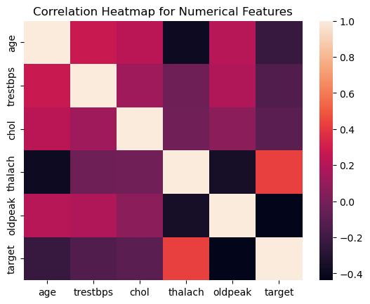

```python
sns.heatmap(df_scaled.corr()).set(title="Correlation Heatmap for Numerical Features")
```

#### Heatmap Analysis:

- We can see that 'oldpeak' and 'target' have strong Inverse Correlation.
- We can see that 'thalach' and 'target' have strong Direct Correlation.
- Strangely, we can see that 'age' and 'target' have inverse Correlation.

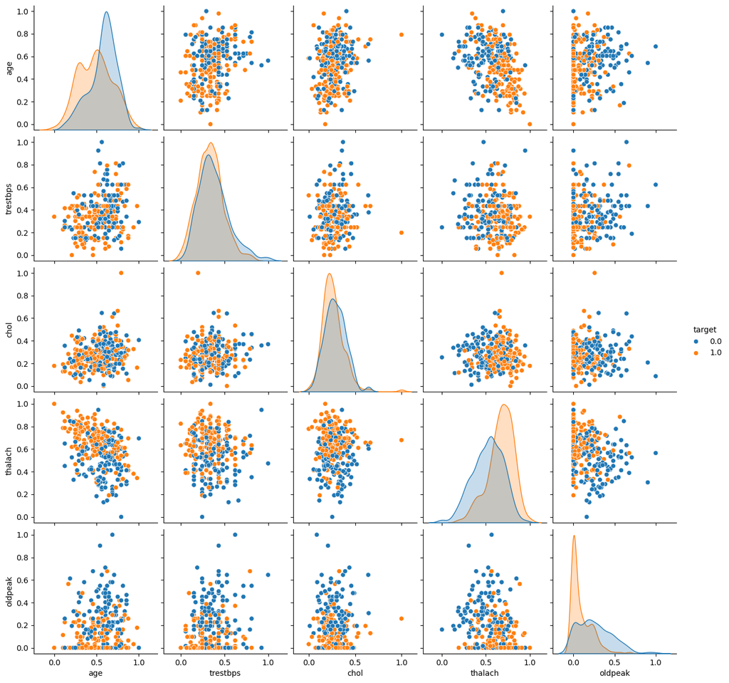

```python
sns.pairplot(df_scaled, hue='target')
```

#### Observations From The Above Pairplot:

- We can see that the higher value of 'thalach' is strongly related in patients with heart disease.
- We can see that the lower value of 'oldpeak' is strongly related in patients with heart disease.

```python
# Melting across variables by 'target' column
df_long = df_scaled.melt(id_vars=['target'])
```

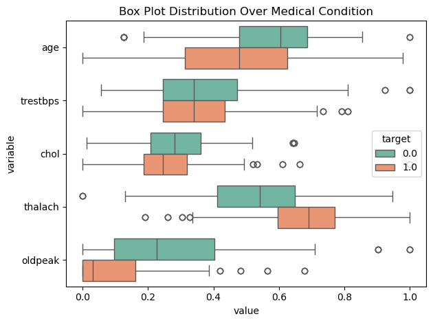

```python
# Box Plot Analysis for Feature Selection
ax = sns.boxplot(data=df_long, x="value", y="variable", orient="h", palette="Set2", hue="target").set(title="Box Plot Distribution Over Medical Condition")
plt.tight_layout()
plt.show()
```

#### Observations Confirmation From The Boxplots:

All our above confirmations regarding correlations between variables also get confirmed through box plot EDA.

- We can see that the higher value of 'thalach' is strongly related in patients with heart disease.
- We can see that the lower value of 'oldpeak' is strongly related in patients with heart disease.

### EDA for Categorical Variables

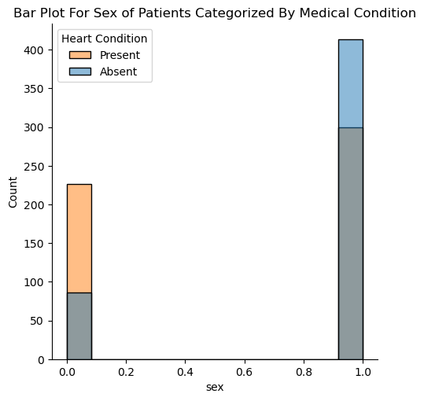

```python
sns.displot(df,  x='sex', hue='target', legend = False).set(title="Bar Plot For Sex of Patients Categorized By Medical Condition")
plt.legend(title='Heart Condition', labels=['Present', 'Absent'])
```

From the dataset, The dataset has around 70% of male entries (sex == 1) and 30% female (sex == 0) entries.

- We can observe that number of women who have heart condition is more than women who do not have heart condition.
- We can observe that number of men who have heart condition is less than the number of men who do not have heart condition.

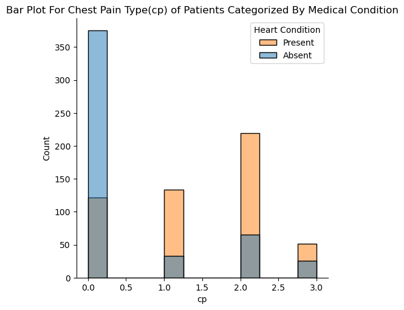

```python
sns.displot(df,  x='cp', hue='target', legend = False).set(title="Bar Plot For Chest Pain Type(cp) of Patients Categorized By Medical Condition")
plt.legend(title='Heart Condition', labels=['Present', 'Absent'])
```

From the plot,

- We can observe that chest pain type (1, 2, and 3) have greater than 1 ratio for disease/no_disease.
- We can observe that chest pain type (0) have smaller than 1 ration for disease/no_disease

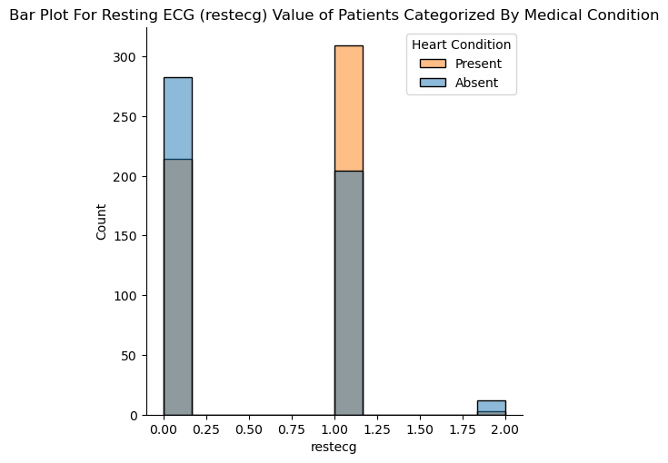

```python
sns.displot(df,  x='restecg', hue='target', legend = False).set(title="Bar Plot For Resting ECG (restecg) Value of Patients Categorized By Medical Condition")
plt.legend(title='Heart Condition', labels=['Present', 'Absent'])
```

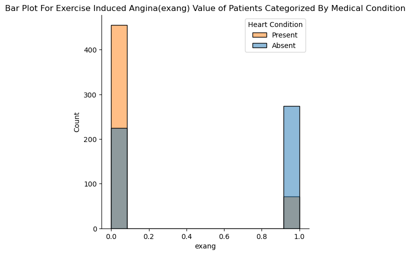

```python
sns.displot(df,  x='exang', hue='target', legend = False).set(title="Bar Plot For Exercise Induced Angina(exang) Value of Patients Categorized By Medical Condition")
plt.legend(title='Heart Condition', labels=['Present', 'Absent'])
```

From the dataset,

- We can observe that exang with value = 0 has greater than 1 ratio for disease/no_disease.
- We can observe that exang with value = 1 has smaller than 1 ration for disease/no_disease

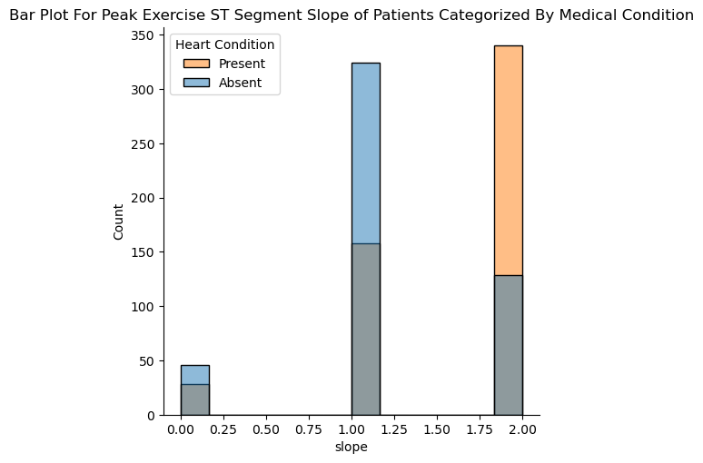

```python
sns.displot(df,  x='slope', hue='target', legend = False).set(title="Bar Plot For Peak Exercise ST Segment Slope of Patients Categorized By Medical Condition")
plt.legend(title='Heart Condition', labels=['Present', 'Absent'])
```

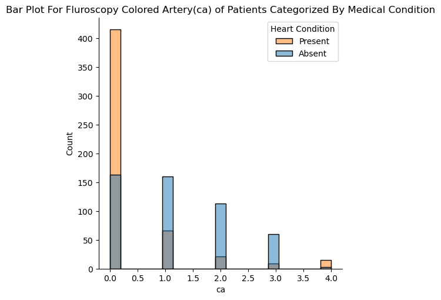

```python
sns.displot(df,  x='ca', hue='target', legend = False).set(title="Bar Plot For Fluroscopy Colored Artery(ca) of Patients Categorized By Medical Condition")
plt.legend(title='Heart Condition', labels=['Present', 'Absent'])
```

From the dataset,

- We can observe that ca with value = 0 has greater than 1 ratio for disease/no_disease.
- We can observe that ca with value in [1, 2, 3] has smaller than 1 ration for disease/no_disease

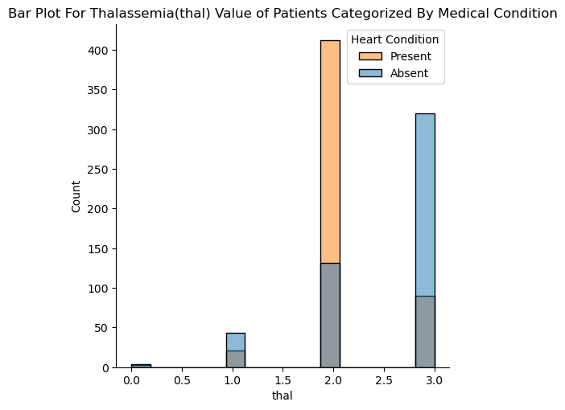

```python
sns.displot(df,  x='thal', hue='target', legend = False).set(title="Bar Plot For Thalassemia(thal) Value of Patients Categorized By Medical Condition")
plt.legend(title='Heart Condition', labels=['Present', 'Absent'])
```

From the dataset,

- We can observe that thal with value = 2 has greater than 1 ratio for disease/no_disease.
- We can observe that thal with value = 3 has smaller than 1 ration for disease/no_disease.
- There are limited entries for thal with value 0 and 1. We cannot derive relationship between these values and presence/absence of heart condition

## 4b. Running the Model

#### Pipeline preprocessing components:

```python
categorical_columns = ['sex', 'cp', 'fbs', 'restecg', 'exang', 'slope', 'ca', 'thal']
categorical_transformer = Pipeline(steps = [
    ('one_hot', OneHotEncoder())
])

numerical_columns = numerical_columns_and_dependent_column[0: -1]
numerical_transformer = Pipeline(steps=[
    ('min_max', MinMaxScaler())
])

column_transformer = ColumnTransformer(transformers = [
    ('categorical', categorical_transformer, categorical_columns),
    ('numerical', numerical_transformer, numerical_columns)
])
```

```python
X = df.iloc[:, :-1]
y = df.iloc[:, -1]
X_train, X_test, y_train, y_test = train_test_split(X, y, random_state = 3)
```

```python
scores = []
n_values = []
for n in range(1, 42, 2):
    knn_classifier = KNeighborsClassifier(n_neighbors=n)
    pipeline = Pipeline(steps = [
        ('column_tansformer', column_transformer),
        ('cross_val_classifier', knn_classifier)
    ])
    score = cross_val_score(pipeline, X_train, y_train, cv=5)
    n_values.append(n)
    scores.append(np.mean(score))
```

[output not shown]

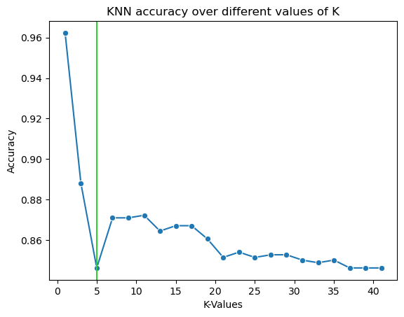

```python
acc_plot = sns.lineplot(x=n_values, y = scores, marker="o")
acc_plot.axvline(x = 5, ymin = 0, ymax = 1, c='limegreen')
acc_plot.set(xlabel="K-Values", ylabel="Accuracy", title="KNN accuracy over different values of K")
```

#### Explanation:

We can see that the model performance starts with almost 100% accuracy on the validation set (N=1), and drops to a minimum value at N=5.

This is because the model is overfitting and memorizing all the values in the training set, causing the accuracy score to be very high initially. Because of this, we will not choose any value of n <= 5 (represented by the values left to the **green** line.

When considering the remaining portion - we will go ahead and choose one of the values with n = 7, 9 and 11 based on feature selection and performance.

**SHORT-LISTED N VALUES = [7, 9, 11]**

## 5. Tinker with parameters

#### Shortlisting features based on the above EDA.

```python
categorical_feature_subset = ['sex', 'cp', 'fbs', 'exang', 'slope', 'ca', 'thal']
numerical_feature_subset = ['age', 'chol', 'thalach', 'oldpeak']

selected_feature_subset = categorical_feature_subset + numerical_feature_subset + ['target']
```

```python
df_feature_selected = df[selected_feature_subset]
```

```python
X = df.iloc[:, :-1]
y = df.iloc[:, -1]
X_train, X_test, y_train, y_test = train_test_split(X, y, test_size = 0.2, random_state = 4)
```

```python
column_transformer_subset = ColumnTransformer(transformers = [
    ('categorical', categorical_transformer, categorical_feature_subset),
    ('numerical', numerical_transformer, numerical_feature_subset)
])
```

#### Tinkering With Different Values of K: [7, 9, 11]

```python
scores = []
n_values_selected = [7, 9, 11]
for n in n_values_selected:
    knn_classifier = KNeighborsClassifier(n_neighbors=n)
    pipeline = Pipeline(steps = [
        ('column_tansformer', column_transformer_subset),
        ('cross_val_classifier', knn_classifier)
    ])
    pipeline.fit(X_train, y_train)
    y_pred = pipeline.predict(X_test)
    acc_scr = accuracy_score(y_test, y_pred)
    precision_scr = precision_score(y_test, y_pred)
    recall_scr = recall_score(y_test, y_pred)
    f1_scr = f1_score(y_test, y_pred)

    print(f"Model Performance Metrics for n = {n}    ")
    print(f"Accuracy Score: {acc_scr}")
    print(f"Precision Score: {precision_scr}")
    print(f"Recall Score: {recall_scr}")
    print(f"F1 Score: {f1_scr}")
    print("**********************************************\n")
```

```
Model Performance Metrics for n = 7
Accuracy Score: 0.8634146341463415
Precision Score: 0.8240740740740741
Recall Score: 0.9081632653061225
F1 Score: 0.8640776699029127

Model Performance Metrics for n = 9
Accuracy Score: 0.8731707317073171
Precision Score: 0.839622641509434
Recall Score: 0.9081632653061225
F1 Score: 0.8725490196078433

Model Performance Metrics for n = 11
Accuracy Score: 0.8829268292682927
Precision Score: 0.87
Recall Score: 0.8877551020408163
F1 Score: 0.8787878787878789
```

## 6. Report the evaluation of your model.

Based on the analysis done so far, we have three potential models that we can select going forward.

**KNN Model with N = 7:**`This model has comparatively lower performance when measured across "Accuracy", "Precision" and "F1 Score". The model is tied on performance when measured over "Recall" score.

**KNN Model with N = 9:**`This model performs slightly better when measured across "Accuracy", "Precision" and "F1 Score" when compared against model with N = 7. Although, its accuracy and precision is slightly weaker than model with N = 11.

**KNN Model with N = 11:**`This model performs better than N=7 and N=9 when measured across "Accuracy", "Precision". The "F1 score" is similar to model N = 9 and has lower recall score compared to model N = 9.

### Final Model

```python
knn_classifier = KNeighborsClassifier(n_neighbors=9)
pipeline = Pipeline(steps = [
        ('column_tansformer', column_transformer_subset),
        ('cross_val_classifier', knn_classifier)
])
pipeline.fit(X_train, y_train)
```

```
Pipeline(steps=[('column_tansformer',
                 ColumnTransformer(transformers=[('categorical',
                                                  Pipeline(steps=[('one_hot',
                                                                   OneHotEncoder())]),
                                                  ['sex', 'cp', 'fbs', 'exang',
                                                   'slope', 'ca', 'thal']),
                                                 ('numerical',
                                                  Pipeline(steps=[('min_max',
                                                                   MinMaxScaler())]),
                                                  ['age', 'chol', 'thalach',
                                                   'oldpeak'])])),
                ('cross_val_classifier', KNeighborsClassifier(n_neighbors=9))])
```

## 7. Create a visualization demonstrating findings.

(A few visualizations have already been done **In-Place** At Various Stages of the Jupyter Notebook.)

#### Creating categories of people for visualization.

```python
import warnings
warnings.filterwarnings('ignore')
df_feature_selected['old'] = np.where(df_feature_selected["age"] >= 60, 1, 0)
old_females = df_feature_selected[(df_feature_selected['old'] == 1) & (df_feature_selected['sex'] == 0)]
old_males = df_feature_selected[(df_feature_selected['old'] == 1) & (df_feature_selected['sex'] == 1)]

young_females = df_feature_selected[(df_feature_selected['old'] == 0) & (df_feature_selected['sex'] == 0)]
young_males = df_feature_selected[(df_feature_selected['old'] == 0) & (df_feature_selected['sex'] == 1)]

without_thalassemia = df_feature_selected[df_feature_selected['thal'] == 0]
with_thalassemia = df_feature_selected[df_feature_selected['thal'] != 0]

categories_of_people = ['old_females', 'old_males', 'young_females', 'young_males', 'without_thalassemia', 'with_thalassemia']
```

```python
old_females_pred = pipeline.predict(old_females.iloc[:, :-2])
old_males_pred = pipeline.predict(old_males.iloc[:, :-2])

young_females_pred = pipeline.predict(young_females.iloc[:, :-2])
young_males_pred = pipeline.predict(young_males.iloc[:, :-2])

without_thal_pred = pipeline.predict(without_thalassemia.iloc[:, :-2])
with_thal_pred = pipeline.predict(with_thalassemia.iloc[:, :-2])

recall_score_per_category = [recall_score(old_females.iloc[:, -2], old_females_pred),
                             recall_score(old_males.iloc[:, -2], old_males_pred),
                             recall_score(young_females.iloc[:, -2], young_females_pred),
                             recall_score(young_males.iloc[:, -2], young_males_pred),
                             recall_score(without_thalassemia.iloc[:, -2], without_thal_pred),
                             recall_score(with_thalassemia.iloc[:, -2], with_thal_pred)]

accuracy_score_per_category = [accuracy_score(old_females.iloc[:, -2], old_females_pred),
                             accuracy_score(old_males.iloc[:, -2], old_males_pred),
                             accuracy_score(young_females.iloc[:, -2], young_females_pred),
                             accuracy_score(young_males.iloc[:, -2], young_males_pred),
                             accuracy_score(without_thalassemia.iloc[:, -2], without_thal_pred),
                             accuracy_score(with_thalassemia.iloc[:, -2], with_thal_pred)]

probability_of_heart_disease = [np.mean(old_females.iloc[:, -2]),
                             np.mean(old_males.iloc[:, -2]),
                             np.mean(young_females.iloc[:, -2]),
                             np.mean(young_males.iloc[:, -2]),
                             np.mean(without_thalassemia.iloc[:, -2]),
                             np.mean(with_thalassemia.iloc[:, -2])]
```

```
[Text(0.5, 1.0, 'Heart Condition Probability Across Categoures')]
```

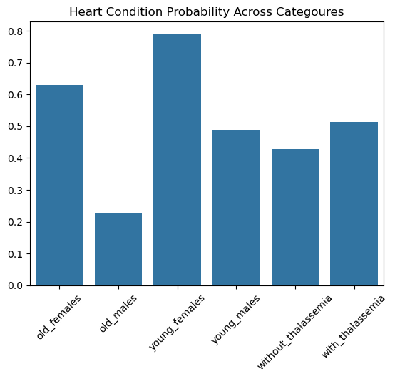

```python
plt = sns.barplot(x=categories_of_people, y=probability_of_heart_disease)
plt.tick_params(axis='x', rotation=45)
plt.set(title="Heart Condition Probability Across Categoures")
```

Based on the above visualization, we see that:

- young females have higher probability of having a heart condition than old females.
- young males have higher probability of having a heart condition than old males.
- In general, female have higher probability of having a heart condition than males.

```
[Text(0.5, 1.0, 'Model Recall Score Across Categoures')]
```

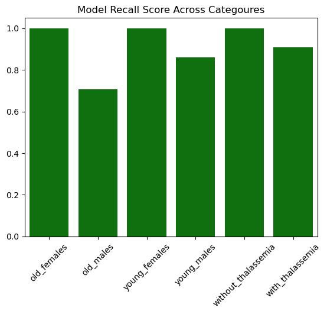

```python
plt = sns.barplot(x=categories_of_people, y=recall_score_per_category, color='green')
plt.tick_params(axis='x', rotation=45)
plt.set(title="Model Recall Score Across Categoures")
```

We observe the following from the above visualization:

- The overall recall score of our model varies slightly across categories, without lowest observed recall score for old_males.
- In, general the model has performed well across categories with more than 0.85 recall score across 5 out of 6 categories.

```
[Text(0.5, 1.0, 'Model Accuracy Score Across Categories')]
```

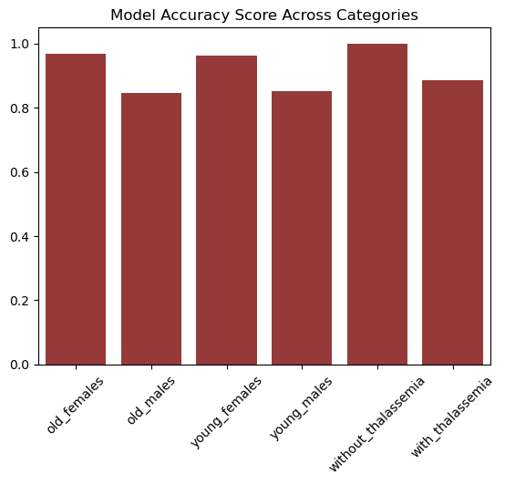

```python
plt = sns.barplot(x=categories_of_people, y=accuracy_score_per_category, color='brown')
plt.tick_params(axis='x', rotation=45)
plt.set(title="Model Accuracy Score Across Categories")
```

## 8. Challenges Encountered

- The main challenge encountered during the design of the solution was no expert consultation to understand the importance of critical features in detecting heart conditions. Although researchers have curated the list to 14 parameters, it was difficult to come up with a list of features to train the model upon. **When developing the model further, it will be important to seek medical science expert opinion, especially in feature selection. This would help overcome this challenge.**
- We also observed overfitting in the training dataset for initial values of K, where the model started memorizing the data points. This occurs because the closest point to any training data point is itself. Hence the prediction is always accurate with K=1. The model performance starts decreasing first for any value greater than K, reaches a minimum, and then starts increasing. **I overcame this challenge by plotting the accuracy vs K graph for different values of the (K)NN model. Then picked the top three values with highest accuracy in the validation set.**
- From the research question perspective, one of the challenges related to data is that data is mainly related to the demography of North America and a few Regions of Europe. As we know there can be variations in observed medical conditions for people across continents, due to factors like environment, body type, heat tolerance, and food habits. It will be challenging to extend this model across the globe. Especially in India, where lifestyle and environmental conditions are different from North America/Europe. **To overcome this challenge, I would require datasets that have regional demography information as well, as it would help me do an extended comparative study.**
- The size of the dataset is only around 1000, which makes it difficult for the algorithm to understand the important features as well. Especially when trying to understand feature correlation using EDA.

## 9. Answering the Research Questions.

### Research Answers:

1. Given the subset of 13 independent variables of the dataset, can we accurately predict the presence or absence of a heart condition for a patient?

**Answer:** Yes, we were able to build a KNN classification model using 11 out of 14 features that predicts the presence or absence of heart condition with 87.3% accuracy.

2. What is the highest recall score that we can achieve for this classification problem?

**Answer:** The recall score that we achieved for this model was 90.8%. This was the performance parameter that was most important for our model as we did not want a high rate of false negatives.

3. What are the top 3 independent variables (bodily conditions/readings) that have a strong direct or inverse correlation with the "target" variable?

**Answer:** Based on the EDA visualizations, the top three categorical and numerical features that have strong direct or inverse correlation are as follows:

Numerical:

- age: The age of the person.
- oldspeak: ST depression induced by exercise relative to rest.
- thalach: Maximum Heart Rate Achieved by the person.

### Risks, Consequences, and Advantages of Applying Model to Unseen Data

**Risk**: Since the model has been trained on people's health data from a specific region in the world (North America, Europe). If applied to the demography of different regions, the risk is that the model might not generalize well to the environmental and lifestyle changes that impact people in different regions of the world. Also, the challenge related to the small size of the dataset has the potential to cause data selection bias, which can lead to erroneous prediction when working with unseen data.

**Consequences of Wrong Prediction**: Since the model is trying to predict the presence or absence of heart condition. The consequences of wrong prediction can be fatal if only the model is relied upon for the assessment of the heart condition. The model is not meant to be the sole predictor but to be used in supplement to the doctor's analysis. The worst-case scenario for this model is when the model does a false negative prediction. That is, NOT predicting HEART CONDITION (disease) when in reality, the person has a HEART CONDITION.

**Advantages of the Model**: The advantage of the model is that it can help in the early diagnosis of the patient and supplement the doctors' diagnosis. As mentioned before as well, the model should not be used as a standalone, but when used with other clinical diagnosis processes, it can help speed up the early diagnosis and help preventive action to be started as soon as possible when the results of other diagnoses get reported. Additionally, when the model is right, it can ascertain the doctor's diagnosis and help in the disease analysis over a while, within a specific demography.

### Negative and Positive Societal Impacts:

**Positives**: Given that the model predicts accurately and performs as per expectation - it can be used in the early diagnosis of heart conditions in medical patients. This can help in a quick start for the preventive or recovery treatment of the person. Also, these kinds of models can further help in the acceptance of real-life applied data science models in day-to-day medical practice. If the model succeeds, it can be customized for each demographic region as well as extended to the diagnosis of other diseases as well.

**Negatives**: Over-reliance or sole dependence on models like these can lead to a wrong diagnosis that can be fatal for patients. This eventually can lead to the negativity/rejection of real-life applied data science in the field of medical diagnosis. As stated and stressed multiple times, these models MUST be used as a supplement to a doctor's diagnosis and NOT USED as standalone predictors.

## 10. Future Research Question:

Q. As the dataset is only restricted to certain regions of North America and Europe (Cleveland, Hungary, Switzerland, and Long Beach V), What is the variation in the ratio of the presence of heart disease in patients across various demographics? To be more specific, what is the percentage of the presence of heart disease conditions in people from different continents of the world having contrasting lifestyles/life expectancies? Can a prediction model be generalized across continents using the same set of features (independent variables)?

**IMPORTANCE**

It is important because, then only this model can be extended and adapted across various medical clinics, and claims for effective adoption of the model be strengthened. This will ensure that the model is able to perform as per expectation on unseen data as well.

## 11. Model Card

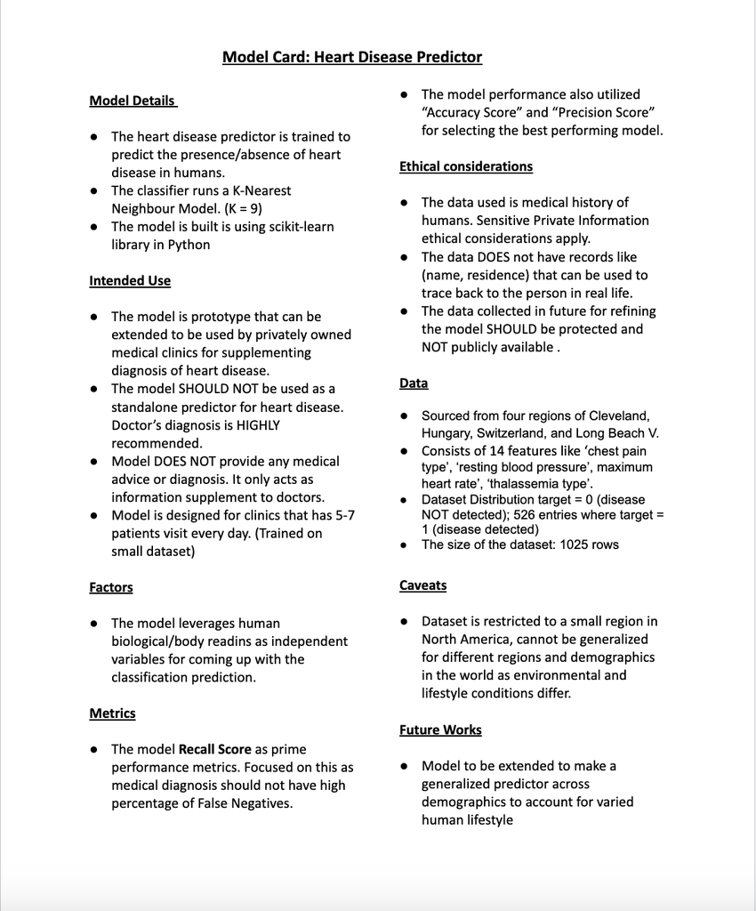

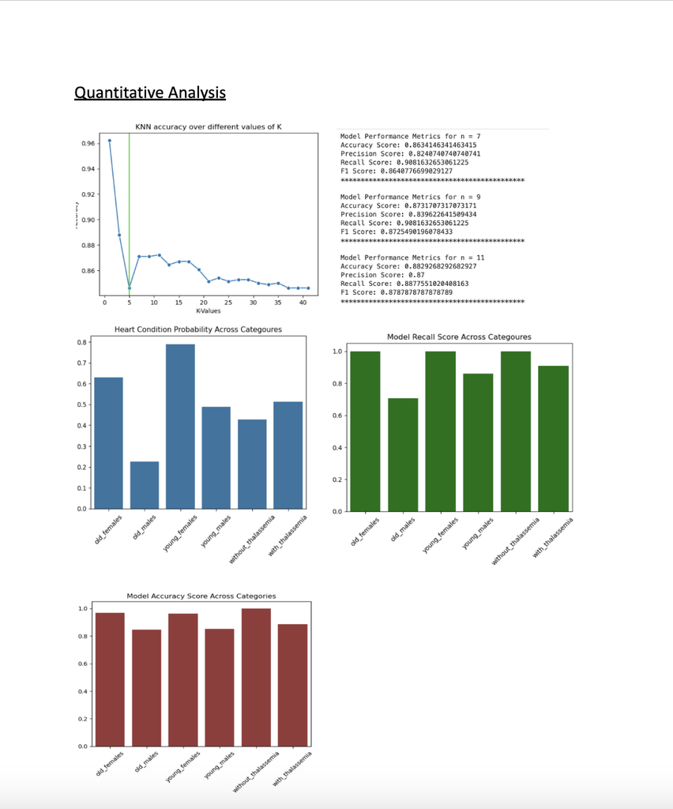